# Exploring Air Quality Determining Factors in Visakhapatnam Using Data Analysis

This is a course project as part of my zerotopandas course from jovian.ml.The course is really awesome and made me understood what really data analysis and how it can be used to solve real life problems...

**Introduction**

This project aims to analyze and explore the air quality determining factors in Visakhapatnam over the course of nearly one year. The dataset used in this analysis contains various parameters such as From Date, PM2.5, PM10, NO, NO2, NOx, NH3, SO2, CO, Ozone, Benzene, Toluene, Temperature (Temp), Relative Humidity (RH), Wind Speed (WS), Wind Direction (WD), Solar Radiation (SR), Barometric Pressure (BP), Virtual Wind Speed (VWS), Ambient Temperature (AT), Rainfall (RF), Xylene, and Total Rainfall (TOT-RF).

**Dataset Source**

The dataset for this project was obtained from https://cpcb.nic.in/. It is crucial to provide proper attribution to the dataset source to ensure transparency and acknowledge the efforts of data collectors and providers.

**Project Objectives**

The primary objectives of this project are to gain insights into the air quality determining factors in Visakhapatnam and their potential impact on the environment and public health. By analyzing the dataset, my specific objectives include:

*Temporal Analysis:* Explore the temporal patterns and trends of various air quality parameters over the course of nearly one year. By examining the data at different time intervals (daily, monthly, seasonal), we aim to identify patterns of variation and potential seasonality in air quality factors.

*Pollutant Assessment:* Evaluate the levels of pollutants such as PM2.5, PM10, NO2, SO2, CO, and others, and assess their compliance with regulatory standards or guidelines. This analysis will provide an overview of the air pollution levels in Visakhapatnam and help identify periods of elevated pollution.

*Correlation Analysis:* Investigate the relationships and correlations among different air quality factors. By examining the interdependencies between variables such as temperature, humidity, wind speed, and pollutant concentrations, we aim to identify potential contributing factors to air pollution.

*Data Visualization:* Utilize Python libraries like **Pandas, Matplotlib, NumPy, and Seaborn** to generate informative and visually appealing plots and charts. Through data visualization techniques, we aim to effectively communicate the findings of the analysis and highlight significant trends or relationships.

By accomplishing these objectives, we aim to contribute to the understanding of air quality in Visakhapatnam, facilitate evidence-based decision-making, and support initiatives for improving environmental conditions and public health.

## Downloading the Dataset

I have downloaded the dataset from source mentioned previously.And I have uploaded it to kaggle datasets website.I use opendatasheets library to download it from kaggle website.

```python
!pip install jovian opendatasets --upgrade --quiet
```

Let's begin by downloading the data, and listing the files within the dataset.

```python
dataset_url = 'https://www.kaggle.com/gagandeepdunna/air-quality-analysis-of-visakhapatnam'
```

```python
import opendatasets as od
od.download(dataset_url)
```

```
Please provide your Kaggle credentials to download this dataset. Learn more: http://bit.ly/kaggle-creds
Your Kaggle username: gagandeepdunna
Your Kaggle Key: ········
Downloading air-quality-analysis-of-visakhapatnam.zip to ./air-quality-analysis-of-visakhapatnam
```

The dataset has been downloaded and extracted.

```python
data_dir = './air-quality-analysis-of-visakhapatnam'
```

```python
import os
os.listdir(data_dir)
```

```
['site_data.csv']
```

Let us save and upload our work to Jovian before continuing.

```python
project_name = "zerotopandas-course-project-air-quality-analysis-of-visakhapatnam"
```

```python
!pip install jovian --upgrade -q
```

```python
import jovian
```

```python
jovian.commit(project=project_name)
```

```
[jovian] Updating notebook "gagandeepdunna9/zerotopandas-course-project-air-quality-analysis-of-visakhapatnam" on https://jovian.com
[jovian] Committed successfully! https://jovian.com/gagandeepdunna9/zerotopandas-course-project-air-quality-analysis-of-visakhapatnam
```

```
'https://jovian.com/gagandeepdunna9/zerotopandas-course-project-air-quality-analysis-of-visakhapatnam'
```

## Data Preparation and Cleaning

Data preparation and cleaning are crucial steps in any data analysis project, ensuring that the dataset is in a suitable format for analysis and free from inconsistencies or errors. In this project, we have followed a systematic approach to prepare and clean the dataset containing air quality determining factors in Visakhapatnam. The following steps were undertaken:

**Dataset Loading:**

The dataset was loaded into a Pandas DataFrame, a powerful data manipulation tool in Python, allowing easy handling and analysis of the data.

**Dataset Structure Examination:**

An initial exploration of the dataset was conducted using Pandas functions such as head(), info(), and describe(). This step provided insights into the column names, data types, and summary statistics of the variables.

**Handling Missing Values:**

**Handling Duplicate Data:**

Duplicate entries were detected using the duplicated() function, and any duplicates found were removed using the drop_duplicates() function.

**Ensuring Consistent Formatting:**

Consistency in data formatting was ensured throughout the dataset. Date and time variables were appropriately formatted, capitalization was standardized, and any inconsistencies in categorical variables were addressed.

```python
!pip install pandas
```

*Pandas:* Pandas is a popular library for data manipulation and analysis. It provides data structures like DataFrames, which allow for efficient handling and manipulation of tabular data. We will use Pandas to load the dataset, perform data cleaning, filtering, and transformation operations, as well as to conduct exploratory data analysis.

```python
#dataset loading
import pandas as pd

aqi_vskp_df=pd.read_csv('./air-quality-analysis-of-visakhapatnam/site_data.csv')
aqi_vskp_df
```

|  | From Date | PM2.5 | PM10 | NO | NO2 | NOx | NH3 | SO2 | CO | Ozone | ... | RH | WS | WD | SR | BP | VWS | AT | RF | Xylene | TOT-RF |
| --- | --- | --- | --- | --- | --- | --- | --- | --- | --- | --- | --- | --- | --- | --- | --- | --- | --- | --- | --- | --- | --- |
| 0 | 22-06-2022 00:00 | 30.8 | 88.25 | 29.73 | 35.23 | 42.95 | 18.18 | 9.95 | 0.55 | 4.92 | ... | 76.82 | 1.28 | 246.48 | 127.9 | 743.33 | 0 | 30.38 | 0 | 3.17 | 0.0 |
| 1 | 23-06-2022 00:00 | 26.12 | 82.87 | 32.02 | 40.52 | 47.63 | 18.45 | 8.33 | 0.44 | 5.98 | ... | 76.84 | 1.75 | 258.57 | 122.46 | 744.1 | 0.01 | 30.62 | 0 | 2.78 | 0.0 |
| 2 | 24-06-2022 00:00 | 46.25 | 107.55 | 32.86 | 40.7 | 48.41 | 18.43 | 9.34 | 0.5 | 4.84 | ... | 82.11 | 1.65 | 260.97 | 47.69 | 743.4 | 0 | 29.6 | 0 | 3.76 | 0.0 |
| 3 | 25-06-2022 00:00 | 45.49 | 104.7 | 38.21 | 40.32 | 52.54 | 19.82 | 12.18 | 0.67 | 4.13 | ... | 83.63 | 1.57 | 261.78 | 53.62 | 741.73 | 0 | 28.23 | 0.01 | 3.58 | 0.5 |
| 4 | 26-06-2022 00:00 | 33.63 | 84.6 | 23.89 | 36.63 | 38.95 | 18.96 | 10.94 | 0.46 | 4.9 | ... | 80.33 | 1.69 | 242.18 | 110.47 | 742.35 | 0 | 29.46 | 0.19 | 2.68 | 17.5 |
| ... | ... | ... | ... | ... | ... | ... | ... | ... | ... | ... | ... | ... | ... | ... | ... | ... | ... | ... | ... | ... | ... |
| 361 | 18-06-2023 00:00 | 48.93 | 150.86 | 10.94 | 42.11 | 31.35 | 29.23 | 6.44 | 0.66 | 15.22 | ... | 69.04 | 2.35 | 192.73 | 185.72 | 741.49 | 0.03 | 36.5 | 0 | 0.65 | 0.0 |
| 362 | 19-06-2023 00:00 | 34.86 | 94.71 | 13.55 | 39.79 | 31.88 | 29.39 | 11.06 | 0.65 | 14.47 | ... | 76.85 | 2.04 | 207.6 | 83.18 | 742.16 | 0.02 | 31.58 | 0.02 | 0.61 | 2.0 |
| 363 | 20-06-2023 00:00 | 47.96 | 119.27 | 9.84 | 42.75 | 30.78 | 28.23 | 11.79 | 0.57 | 15.82 | ... | 76.26 | 2.16 | 224.24 | 142.33 | 742.32 | 0.03 | 32.19 | 0 | 0.51 | 0.0 |
| 364 | 21-06-2023 00:00 | 31.81 | 90.95 | 12.95 | 41.51 | 32.52 | 22.43 | 7.31 | 0.35 | 15.54 | ... | 72.26 | 2.39 | 247.83 | 170.31 | 742.05 | 0.02 | 33.2 | 0 | 0.39 | 0.0 |
| 365 | 22-06-2023 00:00 | 34 | 133 | 10.3 | 36.1 | 27.6 | 24.7 | 7.3 | 0.33 | 10.9 | ... | 81 | 4.6 | 281 | 8 | 743 | 0 | 31.6 | 0 | 0.2 | 0.0 |

366 rows × 23 columns

```python
#To measure the air quality index,we only need "PM10","PM2.5","NO2","SO2","CO","Ozone","NH3","Temp","RH" these parameters according to CCPB.So,we first filter these values out and check for null values and duplicate values.
#Besides these parameters,I want to consider humidity factor just to analyse it's effects on air quality.
required_df=aqi_vskp_df[["From Date","PM10","PM2.5","NO2","SO2","CO","Ozone","NH3","RH"]]
required_df=required_df.rename(columns={'From Date':'Date'})
required_df
```

|  | Date | PM10 | PM2.5 | NO2 | SO2 | CO | Ozone | NH3 | RH |
| --- | --- | --- | --- | --- | --- | --- | --- | --- | --- |
| 0 | 22-06-2022 00:00 | 88.25 | 30.8 | 35.23 | 9.95 | 0.55 | 4.92 | 18.18 | 76.82 |
| 1 | 23-06-2022 00:00 | 82.87 | 26.12 | 40.52 | 8.33 | 0.44 | 5.98 | 18.45 | 76.84 |
| 2 | 24-06-2022 00:00 | 107.55 | 46.25 | 40.7 | 9.34 | 0.5 | 4.84 | 18.43 | 82.11 |
| 3 | 25-06-2022 00:00 | 104.7 | 45.49 | 40.32 | 12.18 | 0.67 | 4.13 | 19.82 | 83.63 |
| 4 | 26-06-2022 00:00 | 84.6 | 33.63 | 36.63 | 10.94 | 0.46 | 4.9 | 18.96 | 80.33 |
| ... | ... | ... | ... | ... | ... | ... | ... | ... | ... |
| 361 | 18-06-2023 00:00 | 150.86 | 48.93 | 42.11 | 6.44 | 0.66 | 15.22 | 29.23 | 69.04 |
| 362 | 19-06-2023 00:00 | 94.71 | 34.86 | 39.79 | 11.06 | 0.65 | 14.47 | 29.39 | 76.85 |
| 363 | 20-06-2023 00:00 | 119.27 | 47.96 | 42.75 | 11.79 | 0.57 | 15.82 | 28.23 | 76.26 |
| 364 | 21-06-2023 00:00 | 90.95 | 31.81 | 41.51 | 7.31 | 0.35 | 15.54 | 22.43 | 72.26 |
| 365 | 22-06-2023 00:00 | 133 | 34 | 36.1 | 7.3 | 0.33 | 10.9 | 24.7 | 81 |

366 rows × 9 columns

```python
#now,we check for cells that have null values
required_df.isnull()
#now,we should check for cells which have None as their data
required_df[required_df.apply(lambda row: row.astype(str).str.contains('None').any(), axis=1)]
```

|  | Date | PM10 | PM2.5 | NO2 | SO2 | CO | Ozone | NH3 | RH |
| --- | --- | --- | --- | --- | --- | --- | --- | --- | --- |
| 229 | 06-02-2023 00:00 | None | None | None | None | None | None | None | None |

```python
#since,there are cells that have None as their values,we change None to 0.0
required_df=required_df.replace('None','0.0')
required_df[required_df.apply(lambda row: row.astype(str).str.contains('None').any(), axis=1)]
```

|  | Date | PM10 | PM2.5 | NO2 | SO2 | CO | Ozone | NH3 | RH |
| --- | --- | --- | --- | --- | --- | --- | --- | --- | --- |

```python
#there are no cells that have values as none or null.We check for duplicate values now
required_df[required_df.duplicated()]
```

|  | Date | PM10 | PM2.5 | NO2 | SO2 | CO | Ozone | NH3 | RH |
| --- | --- | --- | --- | --- | --- | --- | --- | --- | --- |

```python
#there are no dupliate data either.Now we chnage the data from String format to respective formats like Date and float
dict={"PM10":'float',"PM2.5":'float',"NO2":'float',"SO2":'float',"CO":'float',"Ozone":'float',"NH3":'float',"RH":'float'}
required_df['Date']=pd.to_datetime(required_df["Date"])
required_df=required_df.astype(dict)
print(type(required_df['Date'][0]),type(required_df['PM10'][0]))
```

```
<class 'pandas._libs.tslibs.timestamps.Timestamp'> <class 'numpy.float64'>
```

```python
import jovian
```

```python
jovian.commit()
```

```
[jovian] Updating notebook "gagandeepdunna9/zerotopandas-course-project-air-quality-analysis-of-visakhapatnam" on https://jovian.com
[jovian] Committed successfully! https://jovian.com/gagandeepdunna9/zerotopandas-course-project-air-quality-analysis-of-visakhapatnam
```

```
'https://jovian.com/gagandeepdunna9/zerotopandas-course-project-air-quality-analysis-of-visakhapatnam'
```

## Exploratory Analysis and Visualization

Since we have our cleaned dataset,we will now calculate month-wise average of these quantities in the dataset,calculate the aqi for each month and then compare the data for aqi and humidity.

```python
start_date = pd.to_datetime('2022-06-01')
end_date = pd.to_datetime('2023-06-01')
df_filtered = required_df[(required_df['Date'] >= start_date) & (required_df['Date'] <= end_date)]
df_grouped = df_filtered.groupby([df_filtered['Date'].dt.year, df_filtered['Date'].dt.month]).mean()
df_grouped.index = df_grouped.index.map(lambda x: f"{x[0]}-{x[1]:02d}")
df_grouped=df_grouped.reset_index()
df_grouped=df_grouped.rename(columns={'index':'Period'})
#since june 2023 is not completely available at the time of analysis,we ignore it for now.
df_grouped.drop(df_grouped.tail(1).index,inplace=True)
df_grouped
```

|  | Period | PM10 | PM2.5 | NO2 | SO2 | CO | Ozone | NH3 | RH |
| --- | --- | --- | --- | --- | --- | --- | --- | --- | --- |
| 0 | 2022-06 | 101.480000 | 41.236000 | 35.259333 | 14.633333 | 0.501333 | 10.558000 | 17.814667 | 77.567333 |
| 1 | 2022-07 | 103.484000 | 34.234400 | 32.752000 | 13.687600 | 0.430000 | 8.262400 | 16.146000 | 77.188400 |
| 2 | 2022-08 | 99.315600 | 34.157600 | 32.340800 | 11.379200 | 0.432800 | 9.698800 | 16.679600 | 76.534000 |
| 3 | 2022-09 | 94.337500 | 35.063750 | 34.091667 | 15.149583 | 0.481250 | 17.397917 | 17.453333 | 77.612917 |
| 4 | 2022-10 | 103.791200 | 47.819200 | 30.492000 | 21.398800 | 0.442800 | 22.870400 | 17.248400 | 71.246000 |
| 5 | 2022-11 | 148.002083 | 66.594583 | 44.510000 | 20.839583 | 0.632500 | 24.209167 | 17.283333 | 70.142083 |
| 6 | 2022-12 | 145.622000 | 64.743600 | 34.688400 | 20.061600 | 0.683200 | 21.064000 | 25.074400 | 75.487600 |
| 7 | 2023-01 | 178.866800 | 82.911600 | 39.670400 | 5.951600 | 0.804400 | 16.298800 | 28.365600 | 72.811600 |
| 8 | 2023-02 | 161.888182 | 58.922273 | 35.209091 | 7.510909 | 0.852727 | 14.881818 | 16.659545 | 74.513636 |
| 9 | 2023-03 | 116.432800 | 40.806400 | 37.104400 | 13.961600 | 0.782800 | 18.878000 | 15.412400 | 74.394000 |
| 10 | 2023-04 | 140.202083 | 51.920000 | 34.874583 | 12.859583 | 0.710417 | 19.398750 | 15.774583 | 69.812917 |
| 11 | 2023-05 | 141.676400 | 51.208400 | 38.159600 | 13.552000 | 0.590400 | 20.311600 | 23.127600 | 73.774000 |

```python
!pip install numpy
```

*NumPy:* NumPy is a fundamental library for scientific computing in Python. It provides powerful array and matrix operations, mathematical functions, and tools for handling numerical data. We may use NumPy for calculations, aggregations, and statistical analysis on the air quality dataset. I used numpy here to calculate the sub-index values of each pollutant and to find the aqi by using nanmax function...

```python
#Before going into further analysis ,let us calculate the aqi for each month
#we define breakpoints as per india guidelines for calculation naqi
breakpoints = {
    'PM10': [0, 50, 100, 250, 350, 430],
    'PM2.5': [0, 30, 60, 90, 120, 250],
    'NO2': [0, 25, 50, 100, 200, 400],
    'SO2': [0, 40, 80, 380, 800, 1600],
    'CO': [0, 1, 2, 10, 17, 34],
    'Ozone': [0, 50, 100, 168, 208, 748],
    'NH3': [0, 100, 200, 400, 800, 1200],
    'RH': [0, 40, 60, 80, 100]
}
#let us define a function for calculating sub-index value of each substance
import numpy as np

def calculate_aqi(concentration, breakpoints):
    for i in range(len(breakpoints) - 1):
        if concentration >= breakpoints[i] and concentration <= breakpoints[i+1]:
            aqi = ((breakpoints[i+1] - breakpoints[i]) / (breakpoints[-1] - breakpoints[0])) * 100
            aqi = np.round(aqi, decimals=0)
            return aqi
    return None
#let us create a new column called AQI in the dataframe and then calculate them using max function in numpy...
df_grouped['AQI'] = np.nan

for index, row in df_grouped.iterrows():
    aqi_values = []
    for pollutant in breakpoints.keys():
        concentration = row[pollutant]
        aqi = calculate_aqi(concentration, breakpoints[pollutant])
        aqi_values.append(aqi)
    df_grouped.loc[index, 'AQI'] = np.nanmax(aqi_values)

df_grouped
```

|  | Period | PM10 | PM2.5 | NO2 | SO2 | CO | Ozone | NH3 | RH | AQI |
| --- | --- | --- | --- | --- | --- | --- | --- | --- | --- | --- |
| 0 | 2022-06 | 101.480000 | 41.236000 | 35.259333 | 14.633333 | 0.501333 | 10.558000 | 17.814667 | 77.567333 | 35.0 |
| 1 | 2022-07 | 103.484000 | 34.234400 | 32.752000 | 13.687600 | 0.430000 | 8.262400 | 16.146000 | 77.188400 | 35.0 |
| 2 | 2022-08 | 99.315600 | 34.157600 | 32.340800 | 11.379200 | 0.432800 | 9.698800 | 16.679600 | 76.534000 | 20.0 |
| 3 | 2022-09 | 94.337500 | 35.063750 | 34.091667 | 15.149583 | 0.481250 | 17.397917 | 17.453333 | 77.612917 | 20.0 |
| 4 | 2022-10 | 103.791200 | 47.819200 | 30.492000 | 21.398800 | 0.442800 | 22.870400 | 17.248400 | 71.246000 | 35.0 |
| 5 | 2022-11 | 148.002083 | 66.594583 | 44.510000 | 20.839583 | 0.632500 | 24.209167 | 17.283333 | 70.142083 | 35.0 |
| 6 | 2022-12 | 145.622000 | 64.743600 | 34.688400 | 20.061600 | 0.683200 | 21.064000 | 25.074400 | 75.487600 | 35.0 |
| 7 | 2023-01 | 178.866800 | 82.911600 | 39.670400 | 5.951600 | 0.804400 | 16.298800 | 28.365600 | 72.811600 | 35.0 |
| 8 | 2023-02 | 161.888182 | 58.922273 | 35.209091 | 7.510909 | 0.852727 | 14.881818 | 16.659545 | 74.513636 | 35.0 |
| 9 | 2023-03 | 116.432800 | 40.806400 | 37.104400 | 13.961600 | 0.782800 | 18.878000 | 15.412400 | 74.394000 | 35.0 |
| 10 | 2023-04 | 140.202083 | 51.920000 | 34.874583 | 12.859583 | 0.710417 | 19.398750 | 15.774583 | 69.812917 | 35.0 |
| 11 | 2023-05 | 141.676400 | 51.208400 | 38.159600 | 13.552000 | 0.590400 | 20.311600 | 23.127600 | 73.774000 | 35.0 |

Let's begin by importing`matplotlib.pyplot` and `seaborn`.

*Matplotlib:* Matplotlib is a comprehensive library for creating static, animated, and interactive visualizations in Python. We will utilize Matplotlib to generate various types of plots and charts, including line plots, scatter plots, bar plots, histograms, and box plots. These visualizations will help us understand the patterns, trends, and relationships within the air quality data.

*Seaborn:* Seaborn is a high-level data visualization library that works in conjunction with Matplotlib. It offers a simplified API and provides aesthetically pleasing statistical graphics. We will utilize Seaborn to create visually appealing and informative plots that enhance our understanding of the air quality factors.

Here,I imported seaborn and matplotlib library.I have set seaborn library to dark grid with font-size of 12px and fig size of 12X5 grid.

```python
import seaborn as sns
import matplotlib
import matplotlib.pyplot as plt
%matplotlib inline

sns.set_style('darkgrid')
matplotlib.rcParams['font.size'] = 12
matplotlib.rcParams['figure.figsize'] = (12, 5)
matplotlib.rcParams['figure.facecolor'] = '#00000000'
df_grouped.head()
```

|  | Period | PM10 | PM2.5 | NO2 | SO2 | CO | Ozone | NH3 | RH | AQI |
| --- | --- | --- | --- | --- | --- | --- | --- | --- | --- | --- |
| 0 | 2022-06 | 101.4800 | 41.23600 | 35.259333 | 14.633333 | 0.501333 | 10.558000 | 17.814667 | 77.567333 | 35.0 |
| 1 | 2022-07 | 103.4840 | 34.23440 | 32.752000 | 13.687600 | 0.430000 | 8.262400 | 16.146000 | 77.188400 | 35.0 |
| 2 | 2022-08 | 99.3156 | 34.15760 | 32.340800 | 11.379200 | 0.432800 | 9.698800 | 16.679600 | 76.534000 | 20.0 |
| 3 | 2022-09 | 94.3375 | 35.06375 | 34.091667 | 15.149583 | 0.481250 | 17.397917 | 17.453333 | 77.612917 | 20.0 |
| 4 | 2022-10 | 103.7912 | 47.81920 | 30.492000 | 21.398800 | 0.442800 | 22.870400 | 17.248400 | 71.246000 | 35.0 |

**Trend Analysis of Pollutant Levels Over Time (Line Plot)**

Line plot with the x-axis representing the 'Period' column (months and years) and the y-axis representing the pollutant levels.

```python
Periods=df_grouped.Period
PM10=df_grouped.PM10
PM2=df_grouped['PM2.5']
Ozone=df_grouped.Ozone
```

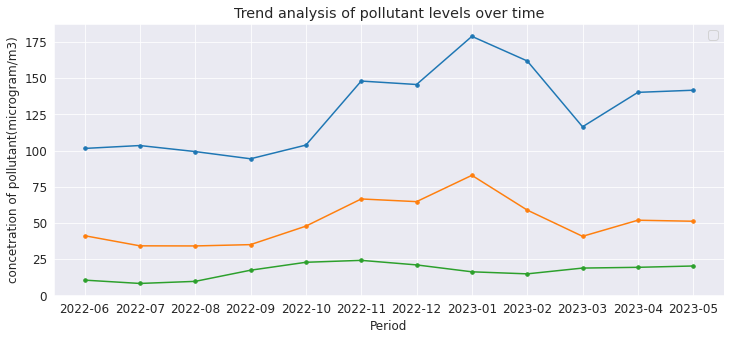

```python
plt.xlabel('Period')
plt.ylabel('concetration of pollutant(microgram/m3)')

plt.title('Trend analysis of pollutant levels over time')
plt.legend(["PM10","PM2.5","Ozone"])

plt.plot(Periods,PM10,marker=".",ms=7)
plt.plot(Periods,PM2,marker=".",ms=7)
plt.plot(Periods,Ozone,marker=".",ms=7)
plt.show()
```

**Distribution of Pollutant Levels (Histogram)**

Histogram plot showing the frequency distribution of a specific pollutant level on the x-axis and the frequency/count on the y-axis.

```python
CO=df_grouped.CO
```

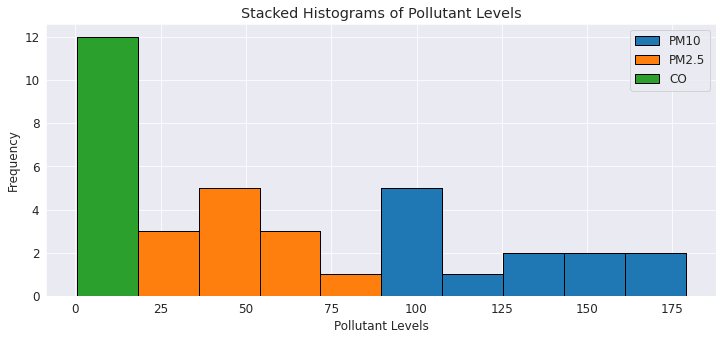

```python
plt.hist([PM10,PM2,CO], bins=10, edgecolor='black', label=['PM10', 'PM2.5', 'CO'],stacked=True)
plt.xlabel('Pollutant Levels')
plt.ylabel('Frequency')
plt.title('Stacked Histograms of Pollutant Levels')
plt.legend(['PM10', 'PM2.5', 'CO'])
plt.show()
```

**Correlation between Pollutant Levels (Scatter Plot Matrix)**  
Scatter plot matrix comparing multiple pollutant levels against each other.

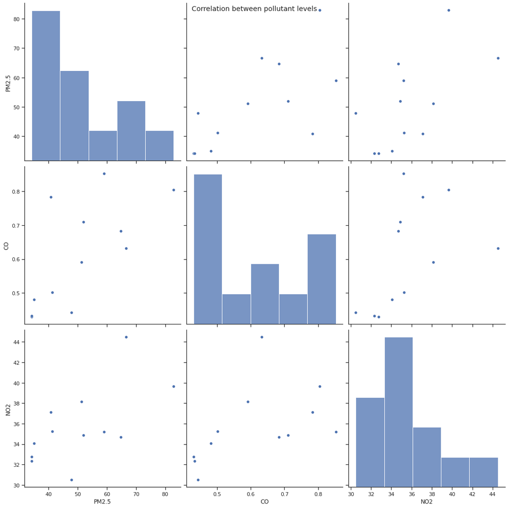

```python
import seaborn as sns
import pandas as pd
import matplotlib.pyplot as plt

pollutants = ['PM2.5', 'CO', 'NO2']
subset_df = df_grouped[pollutants]

# Generate the scatter plot matrix

sns.set(style='ticks')
sns.pairplot(subset_df,height=5).fig.suptitle("Correlation between pollutant levels")
plt.show()
```

From the scatter plot matrix generated using the given data for PM2.5, CO, and NO2 pollutants, we can infer the following:

**PM2.5 vs. CO:**

There seems to be a positive correlation between PM2.5 and CO levels, as indicated by the general upward trend of the scattered points. This suggests that higher levels of CO might be associated with higher levels of PM2.5.

**PM2.5 vs. NO2:**

There appears to be a positive correlation between PM2.5 and NO2 levels, as indicated by the upward trend of the scattered points. This suggests that higher levels of NO2 might be associated with higher levels of PM2.5.

**CO vs. NO2:**

There seems to be a weak positive correlation between CO and NO2 levels, as indicated by the scattered points that show a slight upward trend. This suggests that there might be some association between the two pollutants, but it is not as strong as the correlation observed between PM2.5 and CO or PM2.5 and NO2.

**Monthly Average Pollutant Levels (Bar Plot):**

Bar plot with the x-axis representing the 'Period' column (months) and the y-axis representing the average pollutant levels.

```python
NO2=df_grouped['NO2']
SO2=df_grouped['SO2']
```

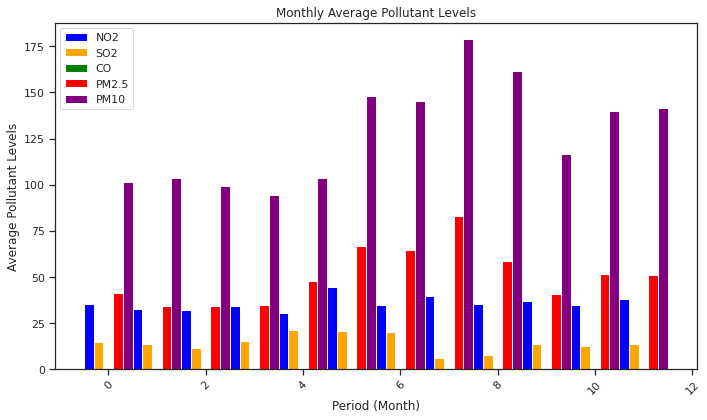

```python
pollutants = ['NO2', 'SO2', 'CO', 'PM2.5', 'PM10']
colors = ['blue', 'orange', 'green', 'red', 'purple']

# Calculate the number of pollutants and the width for each bar
num_pollutants = len(pollutants)
bar_width = 1 / num_pollutants

# Create the bar plot
plt.figure(figsize=(10, 6))
for i, pollutant in enumerate(pollutants):
    x = np.arange(len(Periods)) + (i - (num_pollutants - 1) / 2) * bar_width
    plt.bar(x, df_grouped[pollutant], width=bar_width, color=colors[i], label=pollutant)

# Customize the plot
plt.xlabel('Period (Month)')
plt.ylabel('Average Pollutant Levels')
plt.title('Monthly Average Pollutant Levels')
plt.legend()
plt.xticks(rotation=45)

plt.show()
```

From the given bar plot of monthly average pollutant levels, we can infer the following:

- PM10 levels are consistently higher compared to other pollutants throughout the months.
- Among the pollutants, NO2 levels show relatively less variation across the months.
- SO2 and CO levels exhibit moderate variation with some higher values observed in specific months.
- PM2.5 levels show relatively lower values compared to PM10 but still exhibit some variability across the months.
- The overall pollutant levels tend to be higher during certain months, indicating potential seasonal variations or specific pollution sources during those periods.

Let us save and upload our work to Jovian before continuing

```python
import jovian
```

```python
jovian.commit()
```

```
[jovian] Updating notebook "gagandeepdunna9/zerotopandas-course-project-air-quality-analysis-of-visakhapatnam" on https://jovian.com
[jovian] Committed successfully! https://jovian.com/gagandeepdunna9/zerotopandas-course-project-air-quality-analysis-of-visakhapatnam
```

```
'https://jovian.com/gagandeepdunna9/zerotopandas-course-project-air-quality-analysis-of-visakhapatnam'
```

## Asking and Answering Questions

Asking and answering questions is an essential part of exploring and understanding a dataset. By formulating relevant questions, we can gain insights and make meaningful interpretations of the data. Here, we will demonstrate how to ask and answer questions using the given dataset.

#### Q1:Which pollutant has the highest average level across all months?

```python
#Here we take the data of required pollutants and aggregate them by using mean() function.
pollutants = ['PM2.5', 'CO', 'NO2','SO2','NH3','PM10']
mean_levels = df_grouped[pollutants].mean()
mean_levels.sort_values(ascending=False)
```

```
PM10     127.924887
PM2.5     50.801484
NO2       35.762690
NH3       18.919955
SO2       14.248783
CO         0.612052
dtype: float64
```

As we can see here PM10 and PM2.5 are the pollutants that has highest average level across all months

#### Q2: What are the highest and lowest pollutant levels recorded for each pollutant? Can you find and display this information using summary statistics?

```python
#Here, we consider the data of required pollutants and aggregate them using min and max functions inorder to find the highest and lowest levels for each pollutant.
pollutants = ['PM10', 'PM2.5', 'NO2', 'SO2', 'CO', 'NH3']

max_values = df_grouped[pollutants].max()
min_values = df_grouped[pollutants].min()

print("Maximum Pollutant Levels:")
print(max_values)

print("\nMinimum Pollutant Levels:")
print(min_values)
```

```
Maximum Pollutant Levels:
PM10     178.866800
PM2.5     82.911600
NO2       44.510000
SO2       21.398800
CO         0.852727
NH3       28.365600
dtype: float64

Minimum Pollutant Levels:
PM10     94.3375
PM2.5    34.1576
NO2      30.4920
SO2       5.9516
CO        0.4300
NH3      15.4124
dtype: float64
```

The maximum pollutant levels recorded in the dataset indicate periods of relatively high concentrations of pollutants in the air. For example, the maximum levels of PM10, PM2.5, NO2, SO2, CO, and NH3 were found to be 178.8668, 82.9116, 44.51, 21.3988, 0.852727, and 28.3656 respectively. These high levels suggest potentially poor air quality during those periods. On the other hand, the minimum pollutant levels indicate relatively lower concentrations of pollutants, with values such as 94.3375 for PM10, 34.1576 for PM2.5, 30.492 for NO2, 5.9516 for SO2, 0.43 for CO, and 15.4124 for NH3. These lower levels may indicate periods of cleaner air. Understanding and monitoring these pollutant levels is crucial for assessing air quality and its impact on human health and the environment.

#### Q3:Is there a correlation between relative humidity and pollutant levels?

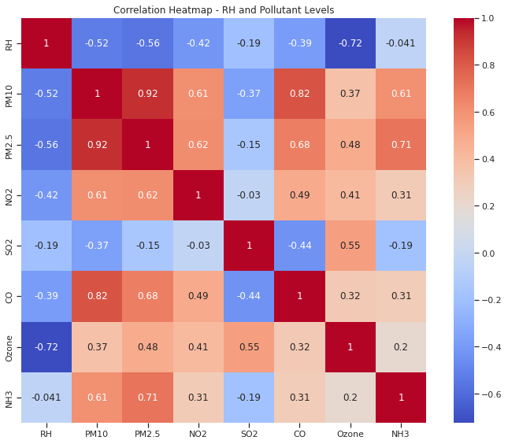

```python
#calculation of correlation coefficients by calculating correlation matrix using corr() function.
correlation_matrix = df_grouped[['RH', 'PM10', 'PM2.5', 'NO2', 'SO2', 'CO', 'Ozone', 'NH3']].corr()
correlation_rh_pollutants = correlation_matrix['RH'][1:]
plt.figure(figsize=(10, 8))
sns.heatmap(correlation_matrix, annot=True, cmap='coolwarm', square=True)
plt.title('Correlation Heatmap - RH and Pollutant Levels')
plt.show()
```

#### Q4: Are there any significant differences in pollutant levels between different seasons?

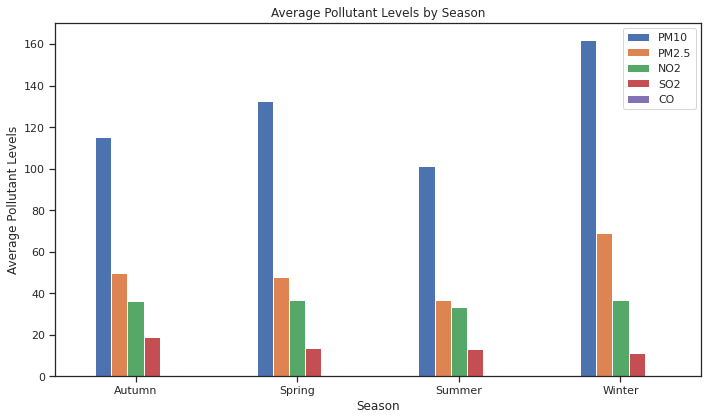

```python
#seperated months based on their seasons and there buy seperating their respective data and then plotted graphs using matplotlib.
df_grouped['YearMonth'] = pd.to_datetime(df_grouped['Period']).dt.to_period('M')
seasons = {'Winter': [12, 1, 2], 'Spring': [3, 4, 5], 'Summer': [6, 7, 8], 'Autumn': [9, 10, 11]}
df_grouped['Season'] = df_grouped['YearMonth'].dt.month.map({month: season for season, months in seasons.items() for month in months})
season_avg = df_grouped.groupby('Season')['PM10', 'PM2.5', 'NO2', 'SO2', 'CO'].mean()
season_avg.plot(kind='bar', figsize=(10, 6))
plt.xlabel('Season')
plt.ylabel('Average Pollutant Levels')
plt.title('Average Pollutant Levels by Season')
plt.legend()
plt.xticks(rotation=0)
plt.show()
```

**From the previously given data, some insights that can be derived are:**

- **PM10 levels:** The PM10 pollutant shows a significant variation throughout the months, with higher levels observed in certain months compared to others. This could be attributed to factors such as weather conditions, industrial activities, or seasonal variations.
- **PM2.5 levels:** The PM2.5 pollutant also exhibits fluctuations over the months, but the levels tend to be lower compared to PM10. However, there are certain months where PM2.5 levels show a noticeable increase, suggesting potential sources or events contributing to the higher levels.
- **NO2 levels:** The NO2 pollutant levels remain relatively consistent throughout the months, with no significant spikes or variations observed. This indicates that the sources of NO2 emissions might be relatively stable or consistent over time.
- **CO levels:** The CO pollutant levels also exhibit stability over the months, with no significant deviations. This suggests a consistent emission pattern or a lack of substantial fluctuations in CO emissions.
- **Seasonal variations:** Analyzing the data on a seasonal basis provides additional insights. The bar plot representing the average pollutant levels by season can help identify any patterns or trends related to specific seasons. For example, it can reveal if certain pollutants tend to be higher during a particular season compared to others.

#### Q5: Is there a correlation between pollutant levels and air quality index (AQI)?

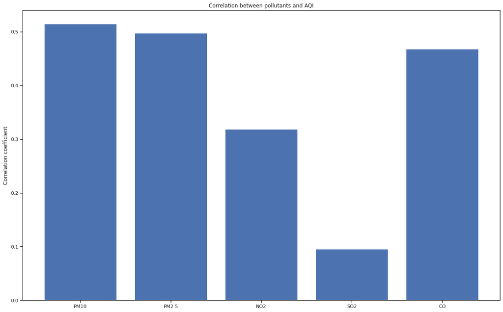

```python
pollutants = ['PM10', 'PM2.5', 'NO2', 'SO2', 'CO']
aqi = df_grouped['AQI']
correlation_matrix = df_grouped[pollutants].corrwith(aqi)

plt.title("Correlation between pollutants and AQI")
plt.ylabel("Correlation coefficient")
plt.bar(pollutants,correlation_matrix)
plt.show()
```

Let us save and upload our work to Jovian before continuing.

```python
import jovian
```

```python
jovian.commit()
```

```
[jovian] Updating notebook "gagandeepdunna9/zerotopandas-course-project-air-quality-analysis-of-visakhapatnam" on https://jovian.com
[jovian] Committed successfully! https://jovian.com/gagandeepdunna9/zerotopandas-course-project-air-quality-analysis-of-visakhapatnam
```

```
'https://jovian.com/gagandeepdunna9/zerotopandas-course-project-air-quality-analysis-of-visakhapatnam'
```

## Inferences and Conclusion

In conclusion, the analysis of the given air quality dataset provided valuable insights into the variations in pollutant levels, their correlations, and their impact on the overall AQI. It highlighted the importance of monitoring and managing pollutants such as PM10, PM2.5, and CO, which had significant associations with air quality. The analysis also indicated the need for further investigation into the specific sources and factors influencing air pollution during certain months. These insights can be useful in developing targeted strategies and interventions to improve air quality and mitigate the impact of pollutants on human health and the environment.

Apart from these,I personally feel so happy and excited to complete this course project.I have come to know how data analysis is done to a certain part and known the importance of data analysis...

```python
import jovian
```

```python
jovian.commit()
```

```
[jovian] Updating notebook "gagandeepdunna9/zerotopandas-course-project-air-quality-analysis-of-visakhapatnam" on https://jovian.com
[jovian] Committed successfully! https://jovian.com/gagandeepdunna9/zerotopandas-course-project-air-quality-analysis-of-visakhapatnam
```

```
'https://jovian.com/gagandeepdunna9/zerotopandas-course-project-air-quality-analysis-of-visakhapatnam'
```

## References and Future Work

- Link for the dataset - https://www.kaggle.com/gagandeepdunna/air-quality-analysis-of-visakhapatnam
- Link for other air quality data in India - https://airquality.cpcb.gov.in/AQI_India/
- Link for Numpy library - https://numpy.org/doc/stable/#
- Link for Pandas library - https://pandas.pydata.org/
- Link for Matplotlib library - https://matplotlib.org/
- Link for Seaborn library - https://seaborn.pydata.org/

**Future Work:** The analysis of the given air quality data provides a foundation for further exploration and future work.I further want to develop interactive visualizations and dashboards to effectively communicate the air quality insights to stakeholders and the general public. This can enhance awareness, understanding, and engagement in air quality management efforts.

```python
import jovian
```

```python
jovian.commit()
```

```
[jovian] Updating notebook "gagandeepdunna9/zerotopandas-course-project-air-quality-analysis-of-visakhapatnam" on https://jovian.com
[jovian] Committed successfully! https://jovian.com/gagandeepdunna9/zerotopandas-course-project-air-quality-analysis-of-visakhapatnam
```

```
'https://jovian.com/gagandeepdunna9/zerotopandas-course-project-air-quality-analysis-of-visakhapatnam'
```